# STAT 184 Final Project

Yi Wang, Yingyu Ma, Ruihan You

2024-04-12

## load the library

```r
knitr::opts_chunk$set(echo = TRUE)
# Load necessary libraries
library(readr)  # For data import
library(dplyr)  # For data manipulation
library(ggplot2)  # For data visualization
library(tidyverse)
library(tinytex)
library(scales)
library(knitr)
library(janitor)
library(kableExtra)
```

## call the data set

```r
AnnualTicketSales <- read.csv(file = "https://raw.githubusercontent.com/STAT184-Spring2024-Sec001/STAT184-Final-Yi-Wang-RuiHan-You-YingyYu-Ma/main/final%20project/AnnualTicketSales.csv")
HighestGrossers <- read.csv(file = "https://raw.githubusercontent.com/STAT184-Spring2024-Sec001/STAT184-Final-Yi-Wang-RuiHan-You-YingyYu-Ma/main/final%20project/HighestGrossers.csv")
PopularCreativeTypes <- read.csv(file = "https://raw.githubusercontent.com/STAT184-Spring2024-Sec001/STAT184-Final-Yi-Wang-RuiHan-You-YingyYu-Ma/main/final%20project/PopularCreativeTypes.csv")
TopDistributors <- read.csv(file = "https://raw.githubusercontent.com/STAT184-Spring2024-Sec001/STAT184-Final-Yi-Wang-RuiHan-You-YingyYu-Ma/main/final%20project/TopDistributors.csv")
TopGenres <- read.csv(file = "https://raw.githubusercontent.com/STAT184-Spring2024-Sec001/STAT184-Final-Yi-Wang-RuiHan-You-YingyYu-Ma/main/final%20project/TopGenres.csv")
TopGrossingRatings <- read.csv(file = "https://raw.githubusercontent.com/STAT184-Spring2024-Sec001/STAT184-Final-Yi-Wang-RuiHan-You-YingyYu-Ma/main/final%20project/TopGrossingRatings.csv")
TopGrossingSources <- read.csv(file = "https://raw.githubusercontent.com/STAT184-Spring2024-Sec001/STAT184-Final-Yi-Wang-RuiHan-You-YingyYu-Ma/main/final%20project/TopGrossingSources.csv")
TopProductionMethods <- read.csv(file = "https://raw.githubusercontent.com/STAT184-Spring2024-Sec001/STAT184-Final-Yi-Wang-RuiHan-You-YingyYu-Ma/main/final%20project/TopProductionMethods.csv")
WideReleasesCount <- read.csv(file = "https://raw.githubusercontent.com/STAT184-Spring2024-Sec001/STAT184-Final-Yi-Wang-RuiHan-You-YingyYu-Ma/main/final%20project/WideReleasesCount.csv")
```

# Introduction

The dataset presented here offers a comprehensive analysis of the theatrical market performance of movies released since 1995 within the North American movie region, encompassing the United States, Canada, Puerto Rico, and Guam. Compiled from The Numbers’ unique categorization system, this dataset provides valuable insights into movie attributes crucial for market understanding.

Market Analysis Criteria Movies in this dataset are categorized based on six key attributes: Creative type (including factual, contemporary fiction, fantasy, etc.), Source (such as book adaptations, original screenplays, etc.), Genre (spanning drama, horror, documentary, and more), MPAA rating, Production method (including live action, digital animation, etc.), and Distributor.

Fair Comparison of Movies To ensure fairness in comparisons across different years, all rankings are rooted in ticket sales data, calculated using average ticket prices as reported annually by the MPAA in their state of the industry reports.

Data Source This dataset is sourced from The Numbers website, focusing specifically on domestic theatrical market performance. The Numbers’ theatrical market pages concentrate on the North American movie region, ensuring a detailed analysis of this specific market. For further details and a deeper exploration of this dataset, please visit The Numbers Market Analysis.

# Research Questions

General question:  
What make the movie earning more money?

To be more specific:  
1. What genres of movies are popular and earning more money?  
2. Does more movie releases leads to a higher total gross? Of the “Big six” movie studios, Walt Disney, Warner Bros., Paramount, 20th century fox, Universal, and Sony, which has a higher number of wide release movie (when a film plays in most cinemas across a country at the same time)?  
3. What movie production method is most profitable?

# Research Question 1

## Some EDA of Q1

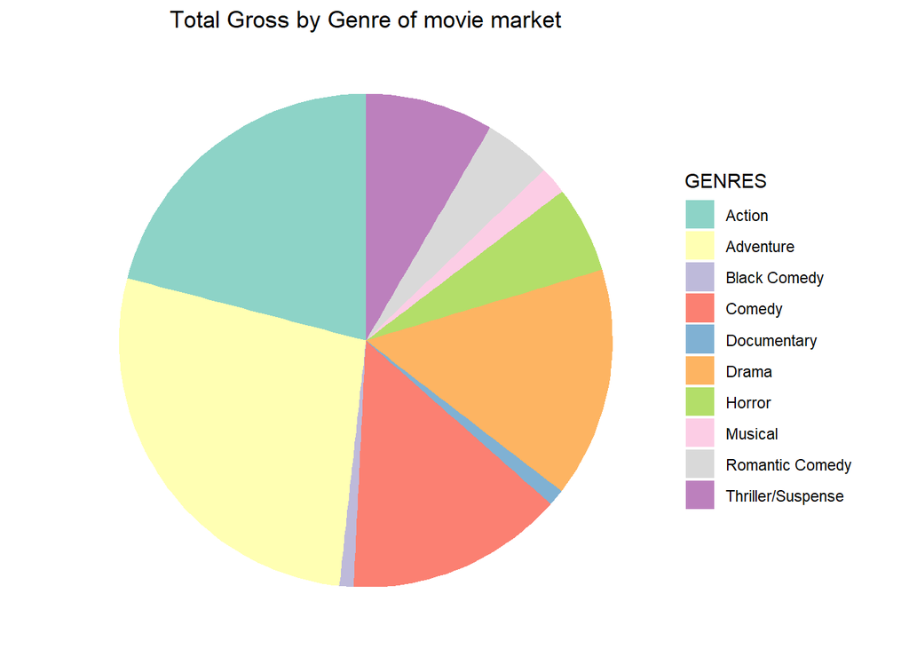

```r
# Data preparation
TopGenres$`TOTAL.GROSS` <- as.numeric(gsub("\\$|,", "", TopGenres$`TOTAL.GROSS`))

# Reorder GENRES based on TOTAL.GROSS
TopGenres <- TopGenres[order(TopGenres$`TOTAL.GROSS`, decreasing = TRUE), ]

# Create a pie chart using ggplot2
ggplot(TopGenres, aes(x = "", y = `TOTAL.GROSS`, fill = GENRES)) +
  geom_bar(width = 1, stat = "identity") +  # Use geom_bar with identity stat to create pie chart effect
  coord_polar("y", start = 0) +  # Convert the bar chart into a pie chart
  theme_void() +  # Remove axes and gridlines
  scale_fill_brewer(palette = "Set3") +  # Set color palette for genres
  labs(title = "Total Gross by Genre of movie market") +  # Chart title
  theme(plot.title = element_text(hjust = 0.5))  # Center the title
```

In order to find out what kind of movie genres are more popular. I decided to first check the popularity share of different movie genres in the market. Therefore pie charts are a good choice for visualization.Pie charts show how different categories relate to each other as parts of a whole. Each slice of the pie represents a category, and its Each slice of the pie represents a category, and its size shows the proportion or percentage of that category relative to the entire dataset.In order to have a more visual view of the market share of each movie genre I chose to use different colors to represent the different genres.Based on the pie chart, the genre of Adventure have the highest market popularity. However, genres pf black comedy, documentary, and musical are the less popular.

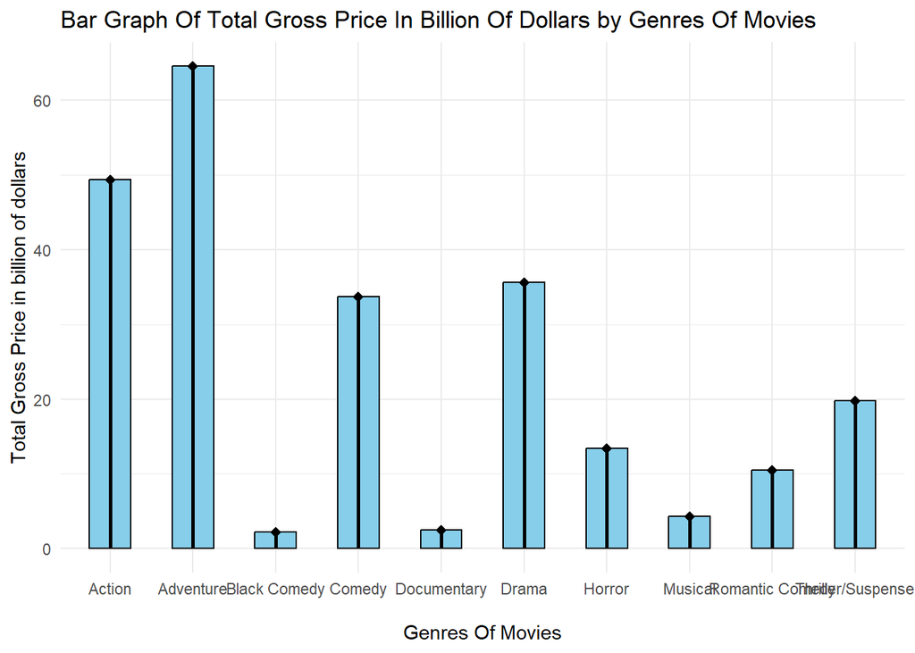

```r
# using ggplot to explore the specific detail of total gross of genres
ggplot(TopGenres, aes(x = GENRES, y = TOTAL.GROSS)) +
  geom_col(width = 0.5, fill = "skyblue", color = "black") +  # Customize bar appearance
  geom_segment(aes(x = GENRES, xend = GENRES, y = 0, yend = TOTAL.GROSS + 5),  # Add pin segments
               color = "black", size = 1) +
  geom_point(aes(x = GENRES, y = TOTAL.GROSS + 5), shape = 18, size = 2.5, color = "black") +# Add pin heads
  labs(x = "\nGenres Of Movies", y = "Total Gross Price in billion of dollars", title = "Bar Graph Of Total Gross Price In Billion Of Dollars by Genres Of Movies") +  # Customize labels
  theme(axis.text.x = element_text(angle = 45, vjust = 1)) +  # Rotate x-axis label
scale_y_continuous(labels = function(x) format(x / 1e9, scientific = FALSE, big.mark = ",", decimal.mark = ".", suffix = "B")) +
  theme_minimal() # Apply a minimal theme
```

# Research Question 2

Does more movie releases leads to a higher total gross? Of the “Big six” movie studios, Walt Disney, Warner Bros., Paramount, 20th century fox, Universal, and Sony, which has a higher number of wide release movie (when a film plays in most cinemas across a country at the same time)?

## EDA - Top Distributors

For the second research question, we want to explore the number of releases of the big six studios and their total gross. Some attributes we are focusing on are:  
Movies - number of movie release Distributors  
Total Gross  
Average Gross

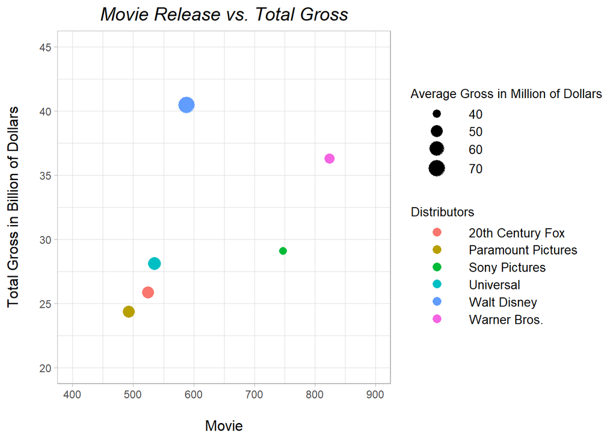

```r
TopDistributors <- TopDistributors[-c(7,8,9,10),] # delete the rows that will not be focused on for this research

# convert total gross and average gross to integers
TopDistributors$TOTAL.GROSS <-  gsub("\\$", "", TopDistributors$TOTAL.GROSS)
TopDistributors$TOTAL.GROSS <-  gsub(",", "", TopDistributors$TOTAL.GROSS)
TopDistributors$TOTAL.GROSS <- as.numeric(TopDistributors$TOTAL.GROSS)
TopDistributors$AVERAGE.GROSS <-  gsub("\\$", "", TopDistributors$AVERAGE.GROSS)
TopDistributors$AVERAGE.GROSS <-  gsub(",", "", TopDistributors$AVERAGE.GROSS)
TopDistributors$AVERAGE.GROSS <- as.numeric(TopDistributors$AVERAGE.GROSS)

# convert the unit of total gross and average gross to billion of dollar and million of dollar
TopDistributors <- TopDistributors %>%
  mutate(TOTAL_GROSS_in_Billion = TOTAL.GROSS/1000000000) %>%
  mutate(AVERAGE_GROSS_in_Million = AVERAGE.GROSS/1000000)


ggplot(TopDistributors) +
  aes(
    x = MOVIES,
    y = TOTAL_GROSS_in_Billion,
    colour = DISTRIBUTORS,
    size = AVERAGE_GROSS_in_Million
  ) +
  geom_point(shape = "circle") + # create the scatter plot where the number of movie is x and the total gross is y, color is the distributors, and size is the average gross
  scale_color_hue(direction = 1) +
  labs(title = "Movie Release vs. Total Gross", color = "Distributors", size = "Average Gross in Million of Dollars") + # add the title and change the label for x and y axis
  xlab("\nMovie") +
  ylab("Total Gross in Billion of Dollars\n") +
  scale_x_continuous(n.breaks = 5, limits = c(400, 900)) +  # change the range scale for x and y axis
  scale_y_continuous(n.breaks = 5, limits = c(20, 45)) +
  scale_size_continuous(limits = c(35, 70)) +
  theme_light() +
  guides(color = guide_legend(override.aes = list(size = 3))) +
  theme(
    plot.title = element_text(size = 15L,
    face = "italic",
    hjust = 0.5),
    axis.title.y = element_text(size = 12L),   # change the size of text and legend
    axis.title.x = element_text(size = 12L),
    legend.text = element_text(size = 10),
    legend.title = element_text(size = 10),
    legend.key.height = unit(0.5, 'cm'),
    legend.key.width = unit(1.5, 'cm')
  )
```

## Analysis

In the scatter plot, we can see that universal, paramount, and 20th century fox are close on their average gross, since the company with more movie releases has a higher total gross. Walt Disney has the highest total gross among those six companies, as well as the highest average gross. And compare to Disney, Warner Bros. has a much greater number of movie release, but lower total gross, and the average gross is the second lowest one. So there we can see that more movie release does not necessarily leads to higher gross, it can be related to other factors.

## EDA - Wide Release

Then we want to compare the number of wide release movie between different distributors. Wide release means a movie play at 600 or more theaters at the same time. The attributes we are focusing on are:  
Distributors  
Wide Release  
Total Release  
Percentage - the percent of wide release movies out of the total number of movie release

```r
# change the column names
colnames(WideReleasesCount) = gsub(pattern = "[[:punct:]]", replacement = " ", x = colnames(WideReleasesCount))
colnames(WideReleasesCount)[4] <- "20TH CENTURY FOX"

WideRelease_FreqTable <- WideReleasesCount[,-c(8,10)] # delete other companies

# covert of number to percentage
summary <- WideRelease_FreqTable %>%
  adorn_totals(where = c("row", "col") ) %>%
  adorn_percentages(denominator = "all") %>%
  adorn_pct_formatting(digits = 2) %>%
  adorn_title(
    placement = "combined",
    row_name = "Year",
    col_name = "Company")
# create format of the table
format <- attr(summary, "core") %>%
  adorn_totals(where = c("row", "col")) %>%
  mutate(
    across(.cols = where(is.numeric),
           .fns = ~format(.x, big.mark = ","))
  )
# combine the number and percentage into the frequency table
wideReleaseFreqTab <- summary %>%
  adorn_ns(position = "front", ns = format)
# present with striped style
wideReleaseFreqTab %>%
  kable(
    caption = "<center>Year and Number of Wide Release for Company<center>",
    booktabs = TRUE,
    align = c("c", rep("c", 6))
  ) %>%
  kableExtra::kable_styling(
    bootstrap_options = c("striped"),
    font_size = 12
  )
```

Year and Number of Wide Release for Company

| Year/Company | WARNER BROS | WALT DISNEY | 20TH CENTURY FOX | PARAMOUNT PICTURES | SONY PICTURES | UNIVERSAL | TOTAL OTHER STUDIOS | Total |
| --- | --- | --- | --- | --- | --- | --- | --- | --- |
| 2021 | 17 (0.48%) | 7 (0.20%) | 0 (0.00%) | 4 (0.11%) | 16 (0.45%) | 17 (0.48%) | 38 (1.07%) | 99 (2.78%) |
| 2020 | 5 (0.14%) | 3 (0.08%) | 1 (0.03%) | 3 (0.08%) | 9 (0.25%) | 13 (0.36%) | 23 (0.65%) | 57 (1.60%) |
| 2019 | 18 (0.51%) | 10 (0.28%) | 11 (0.31%) | 9 (0.25%) | 18 (0.51%) | 21 (0.59%) | 44 (1.23%) | 131 (3.68%) |
| 2018 | 19 (0.53%) | 10 (0.28%) | 11 (0.31%) | 10 (0.28%) | 16 (0.45%) | 20 (0.56%) | 58 (1.63%) | 144 (4.04%) |
| 2017 | 18 (0.51%) | 8 (0.22%) | 14 (0.39%) | 10 (0.28%) | 16 (0.45%) | 15 (0.42%) | 50 (1.40%) | 131 (3.68%) |
| 2016 | 17 (0.48%) | 12 (0.34%) | 16 (0.45%) | 12 (0.34%) | 16 (0.45%) | 22 (0.62%) | 46 (1.29%) | 141 (3.96%) |
| 2015 | 22 (0.62%) | 11 (0.31%) | 18 (0.51%) | 9 (0.25%) | 13 (0.36%) | 20 (0.56%) | 33 (0.93%) | 126 (3.54%) |
| 2014 | 17 (0.48%) | 12 (0.34%) | 17 (0.48%) | 10 (0.28%) | 17 (0.48%) | 15 (0.42%) | 37 (1.04%) | 125 (3.51%) |
| 2013 | 17 (0.48%) | 8 (0.22%) | 15 (0.42%) | 8 (0.22%) | 14 (0.39%) | 16 (0.45%) | 42 (1.18%) | 120 (3.37%) |
| 2012 | 16 (0.45%) | 11 (0.31%) | 15 (0.42%) | 13 (0.36%) | 18 (0.51%) | 17 (0.48%) | 42 (1.18%) | 132 (3.70%) |
| 2011 | 20 (0.56%) | 13 (0.36%) | 15 (0.42%) | 13 (0.36%) | 21 (0.59%) | 19 (0.53%) | 35 (0.98%) | 136 (3.82%) |
| 2010 | 20 (0.56%) | 12 (0.34%) | 18 (0.51%) | 12 (0.34%) | 17 (0.48%) | 17 (0.48%) | 30 (0.84%) | 126 (3.54%) |
| 2009 | 25 (0.70%) | 14 (0.39%) | 20 (0.56%) | 10 (0.28%) | 21 (0.59%) | 21 (0.59%) | 30 (0.84%) | 141 (3.96%) |
| 2008 | 19 (0.53%) | 11 (0.31%) | 22 (0.62%) | 14 (0.39%) | 19 (0.53%) | 19 (0.53%) | 48 (1.35%) | 152 (4.27%) |
| 2007 | 30 (0.84%) | 13 (0.36%) | 17 (0.48%) | 16 (0.45%) | 22 (0.62%) | 20 (0.56%) | 50 (1.40%) | 168 (4.72%) |
| 2006 | 26 (0.73%) | 17 (0.48%) | 25 (0.70%) | 13 (0.36%) | 26 (0.73%) | 21 (0.59%) | 31 (0.87%) | 159 (4.46%) |
| 2005 | 20 (0.56%) | 20 (0.56%) | 19 (0.53%) | 12 (0.34%) | 19 (0.53%) | 17 (0.48%) | 30 (0.84%) | 137 (3.85%) |
| 2004 | 27 (0.76%) | 25 (0.70%) | 18 (0.51%) | 14 (0.39%) | 15 (0.42%) | 14 (0.39%) | 25 (0.70%) | 138 (3.87%) |
| 2003 | 28 (0.79%) | 19 (0.53%) | 13 (0.36%) | 14 (0.39%) | 19 (0.53%) | 13 (0.36%) | 23 (0.65%) | 129 (3.62%) |
| 2002 | 32 (0.90%) | 23 (0.65%) | 15 (0.42%) | 16 (0.45%) | 20 (0.56%) | 13 (0.36%) | 21 (0.59%) | 140 (3.93%) |
| 2001 | 30 (0.84%) | 16 (0.45%) | 16 (0.45%) | 14 (0.39%) | 17 (0.48%) | 10 (0.28%) | 25 (0.70%) | 128 (3.59%) |
| 2000 | 29 (0.81%) | 22 (0.62%) | 13 (0.36%) | 12 (0.34%) | 15 (0.42%) | 13 (0.36%) | 27 (0.76%) | 131 (3.68%) |
| 1999 | 27 (0.76%) | 20 (0.56%) | 15 (0.42%) | 13 (0.36%) | 22 (0.62%) | 16 (0.45%) | 19 (0.53%) | 132 (3.70%) |
| 1998 | 27 (0.76%) | 21 (0.59%) | 11 (0.31%) | 11 (0.31%) | 20 (0.56%) | 16 (0.45%) | 20 (0.56%) | 126 (3.54%) |
| 1997 | 31 (0.87%) | 22 (0.62%) | 12 (0.34%) | 16 (0.45%) | 22 (0.62%) | 11 (0.31%) | 22 (0.62%) | 136 (3.82%) |
| 1996 | 31 (0.87%) | 23 (0.65%) | 13 (0.36%) | 16 (0.45%) | 24 (0.67%) | 13 (0.36%) | 22 (0.62%) | 142 (3.99%) |
| 1995 | 27 (0.76%) | 22 (0.62%) | 11 (0.31%) | 12 (0.34%) | 20 (0.56%) | 17 (0.48%) | 27 (0.76%) | 136 (3.82%) |
| Total | 615 (17.26%) | 405 (11.37%) | 391 (10.97%) | 316 (8.87%) | 492 (13.81%) | 446 (12.52%) | 898 (25.20%) | 3,563 (100.00%) |

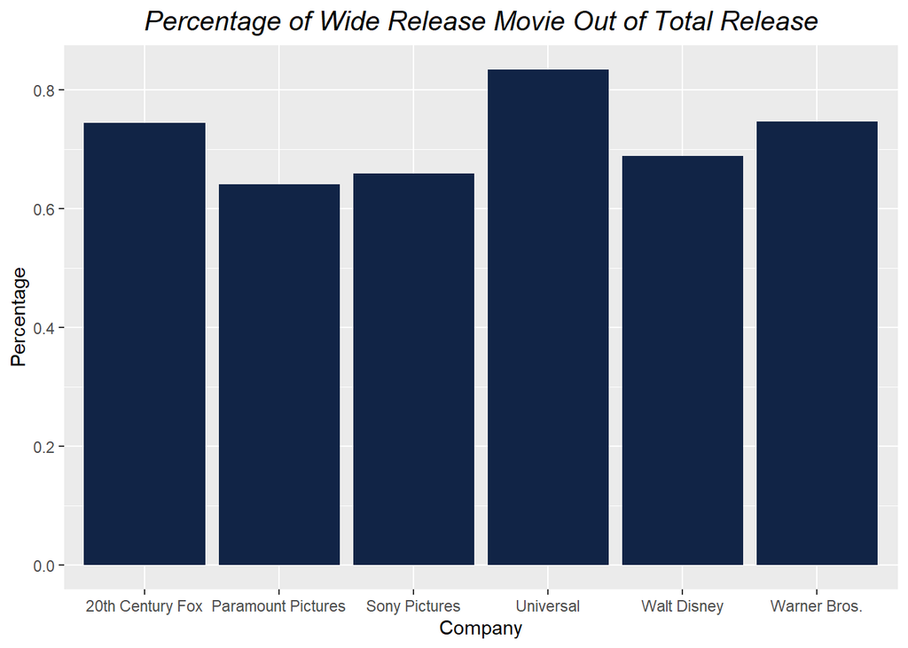

```r
WideReleasesCount <- WideReleasesCount[,-c(8,9,10)] # delete other companies

WideRelease_long <- WideReleasesCount %>% # convert to the Year, Company, Release form
  pivot_longer(!YEAR, names_to = c("Company"), values_to = "Release")

wideRelease_totalNumber <- WideRelease_long %>% # summarize the total number of wide release for each company from 1995 to 2021
  group_by(Company) %>%
  summarise(`Wide Release` = sum(Release))


wideRelease_totalNumber$Company <- str_to_title(wideRelease_totalNumber$Company) # change the format of company name
wideRelease_totalNumber$Company[6] <- "Warner Bros."
wideRelease_totalNumber$`Total Release` <- TopDistributors$MOVIES[match(wideRelease_totalNumber$Company, TopDistributors$DISTRIBUTORS)] # add the total number of release from the top Distributor data set

wideRelease_totalNumber <- wideRelease_totalNumber %>% # calculate the percentage of wide release movie out of total release
  mutate(Percentage = `Wide Release`/`Total Release`)

ggplot(wideRelease_totalNumber) +
  aes(x = Company, y = Percentage) +
  geom_col(fill = "#112446") +
  labs(
    title = "Percentage of Wide Release Movie Out of Total Release"
  ) +
  theme_gray() +
  theme(
    plot.title = element_text(size = 15L,
    face = "italic",
    hjust = 0.5)
  )
```

## Analysis

Based on the frequency table, we can see that the Hollywood market is very centralized, studios other than the Big Six only accounting for 25% of the total number. The major six studios are taking the rest 75%. And for the big six movie studios, Warner Bros., again, has the highest number of wide release movie. But when we compare the number of wide release and total release, we see that Universal Pictures actually has the largest percentage, over 80%, which we can say that the majority of their films are widely released across the country.

# Research Question 3

## EDA Analysis

```r
# filter factors we want to use for further analysis
filtered_production_method <- TopProductionMethods %>%
  select(MOVIES, TOTAL.GROSS, MARKET.SHARE)
```

[output not shown]

## Data Visualization

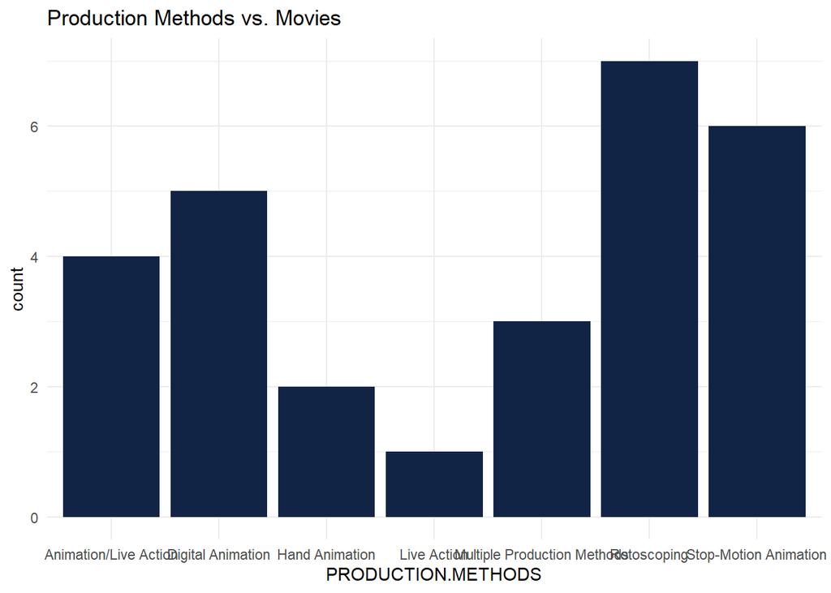

```r
# change movie factor to quantitative variable
TopProductionMethods$MOVIES_factor <- factor(TopProductionMethods$MOVIES)
TopProductionMethods$MOVIES_numeric <- as.numeric(TopProductionMethods$MOVIES_factor)

# use ggplot to create bar chart 1
ggplot(TopProductionMethods) +
  aes(x = PRODUCTION.METHODS, weight = MOVIES_numeric) +
  geom_bar(fill = "#112446") +
  labs(title = "Production Methods vs. Movies") +
  theme_minimal()
```

[figure not shown]

```r
# use ggplot to create bar chart 2
ggplot(TopProductionMethods) +
  aes(x = PRODUCTION.METHODS, y = AVERAGE.GROSS) +
  geom_col(fill = "#112446") +
  labs(title = "Production Method vs. Average Gross") +
  theme_minimal()
```

# Conclusion

According to our EDA we made a bold assumption that adventure produced by Disney World with production method of animation and live action will make most profits money. But as a rigorous statistical scientist, we can’t make judgments and predictions just based on charts and graphs, it’s very uncritical. Hence, if more accurate predictions are needed, we need to build specific models to check which attribute is highly impact with the movie make money. However, due to the limit of knowledge and data support could have to stop at this point.